# Bulk_RNA_SEQ

Jana Elhelw

2025-09-25

# Introduction

This project analyzes gene expression differences between **POU3F2** and **SOX1** knockouts in cortical brain hipsc organoids using RNA-seq. It includes:

- Differential expression analysis using DESeq2
- GO enrichment analysis using:
  - Over-representation analysis (ORA)
  - Gene Set Enrichment Analysis (GSEA)

# Exploratory Data Analysis (EDA)

Used the variance-stabilized transformed data (`vst`) to inspect library quality and relationships between samples.

### Library Size Barplot

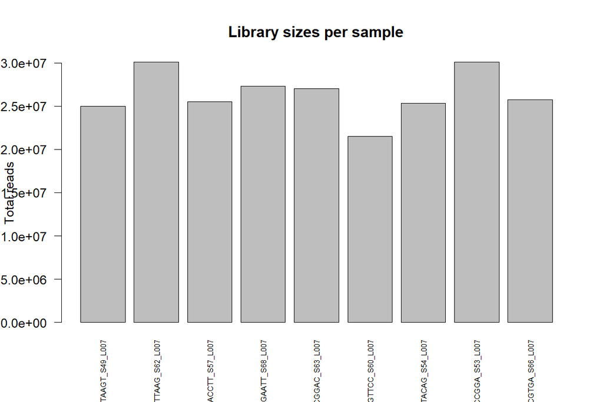

Observation: All samples had comparable total reads, indicating balanced sequencing depth.

### Principal Component Analysis (PCA)

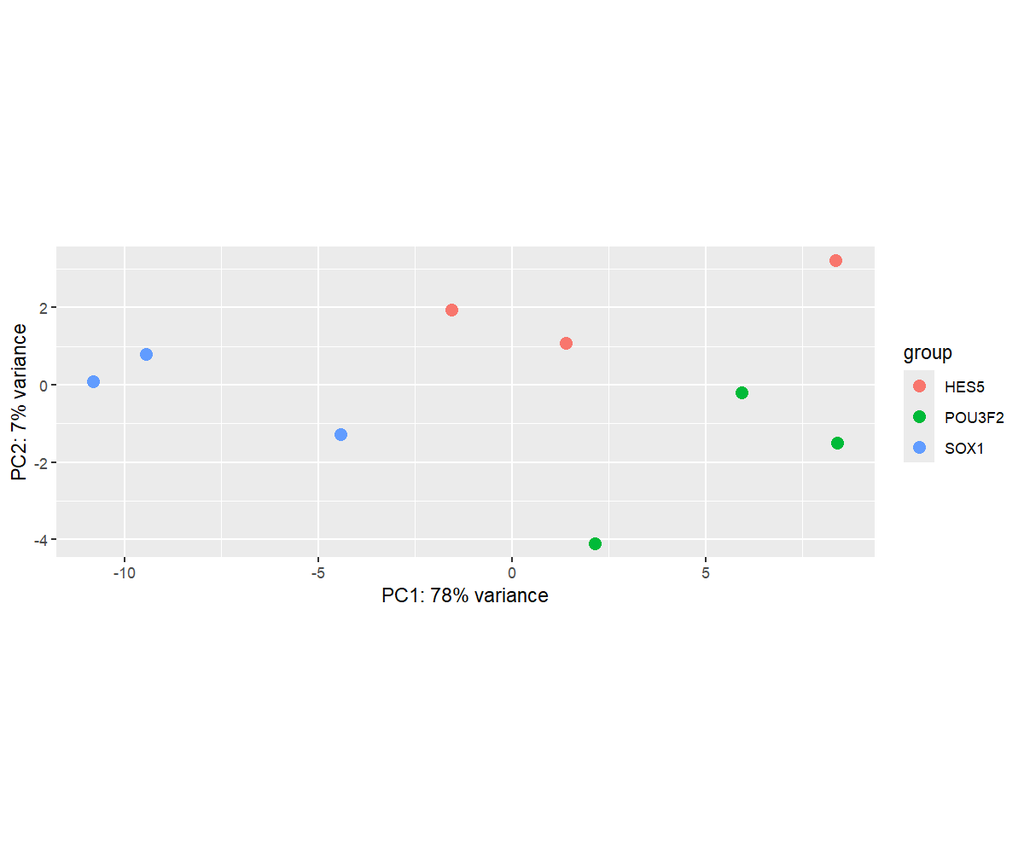

### sample distance heatmap

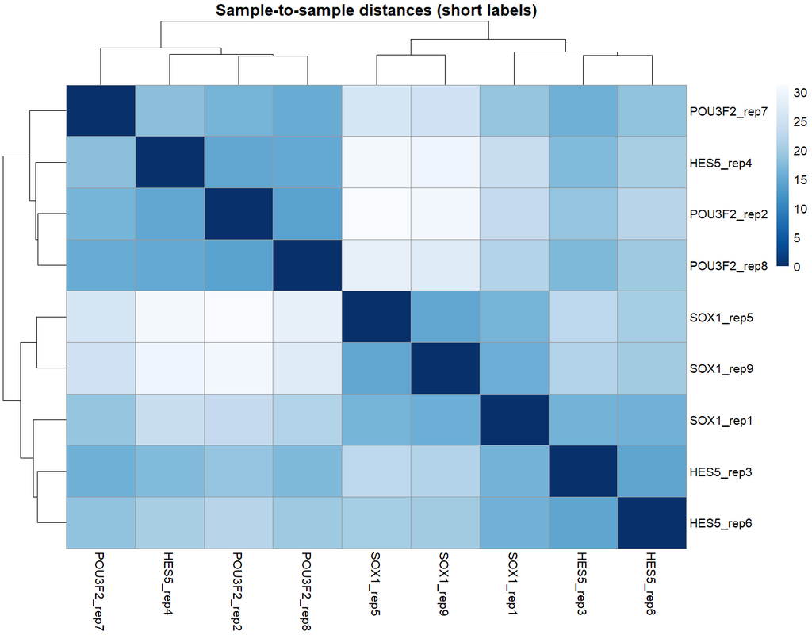

### Top 20 variable genes heatmap

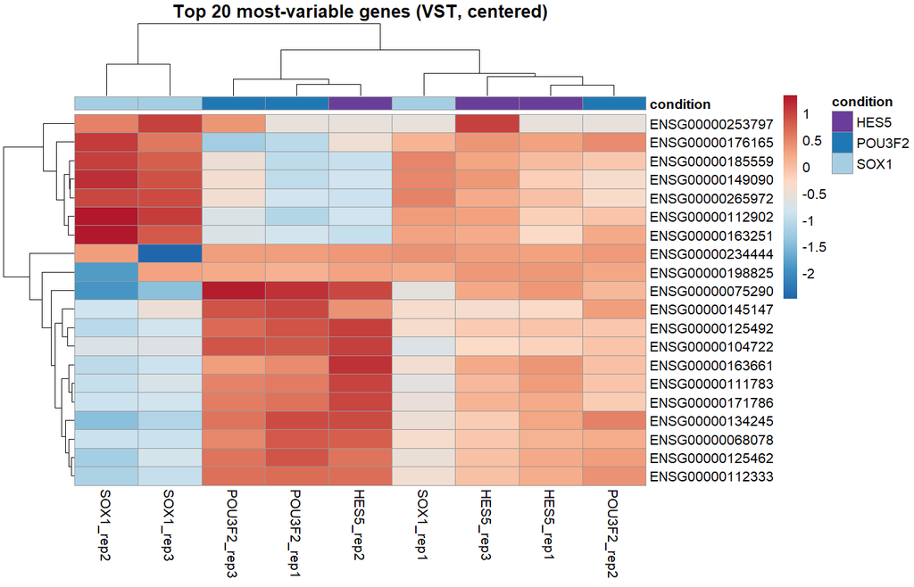

## MA plot for HES5 vs POU3F2

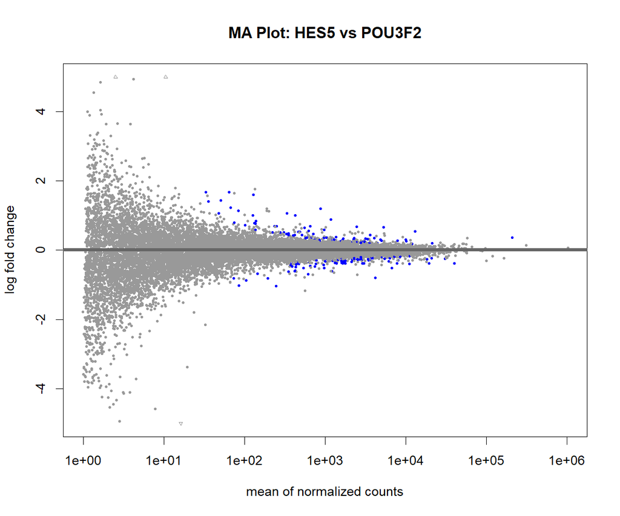

## MA plot for HES5 vs SOX1

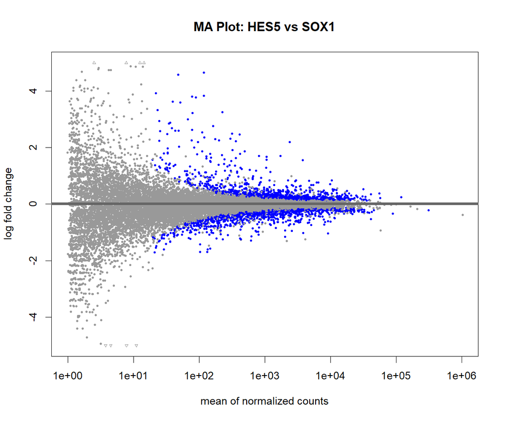

## MA plot for POU3F2 vs SOX1

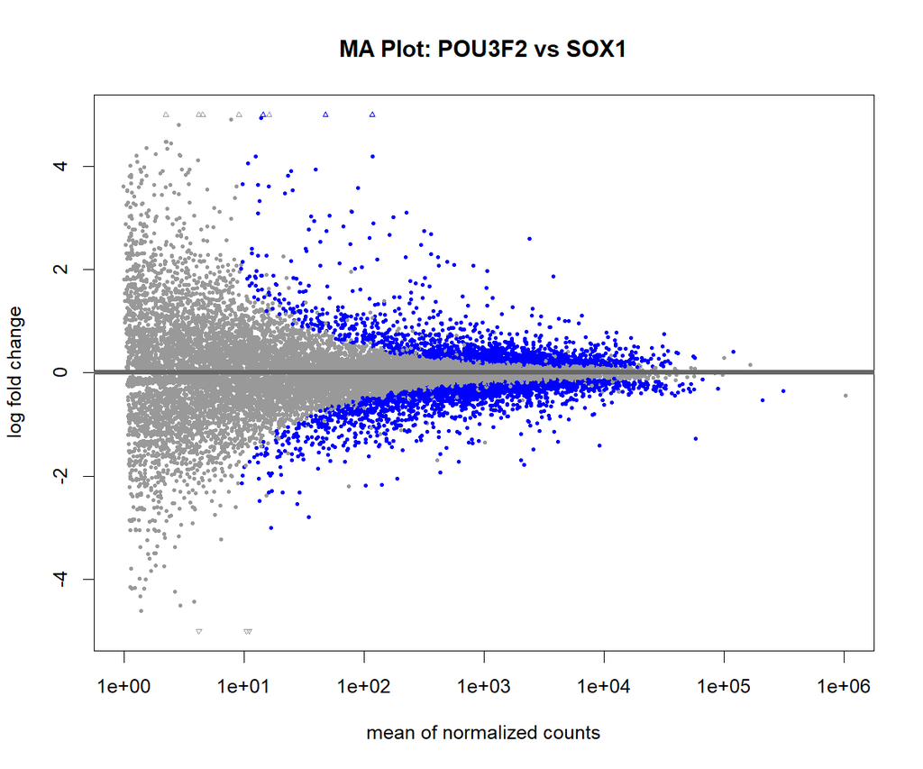

Interpretation: MA plots show that SOX1 KO samples are most distinct (huge number of DE genes). HES5 vs POU3F2 is the most similar comparison (few DE genes) while POU3F2 vs SOX1 show the highest contrast, so this comparison was used for further analysis.

# Differential Expression Analysis (DESeq2)

```
##           ENSEMBL  SYMBOL                                             GENENAME
## 1 ENSG00000184486  POU3F2                               POU class 3 homeobox 2
## 2 ENSG00000160818 GPATCH4        G-patch domain containing 4 (gene/pseudogene)
## 3 ENSG00000129116   PALLD            palladin, cytoskeletal associated protein
## 4 ENSG00000184156   KCNQ3 potassium voltage-gated channel subfamily Q member 3
## 5 ENSG00000261069    <NA>                                                 <NA>
## 6 ENSG00000179546   HTR1D                      5-hydroxytryptamine receptor 1D
##    baseMean log2FoldChange      lfcSE      stat       pvalue         padj
## 1 4178.5904      1.0454056 0.07426998 14.075748 5.353534e-45 8.240159e-41
## 2  758.2992      0.9514863 0.09794712  9.714285 2.620821e-22 2.016984e-18
## 3 7754.8768      0.5602996 0.05798887  9.662192 4.364237e-22 2.239144e-18
## 4  832.4383      0.9037561 0.09426147  9.587757 9.002065e-22 3.463995e-18
## 5 3145.7198     -0.7405652 0.07797814 -9.497087 2.158430e-21 6.644512e-18
## 6  333.8504     -1.1350998 0.12052270 -9.418141 4.591441e-21 1.177858e-17
```

DE results table for POU3F2 vs SOX1 comparison. Used **padj < 0.05** to select significant DEGs.

# GO Enrichment — ORA

ORA was performed using `enrichGO()` from the `clusterProfiler` package on significant DEGs.

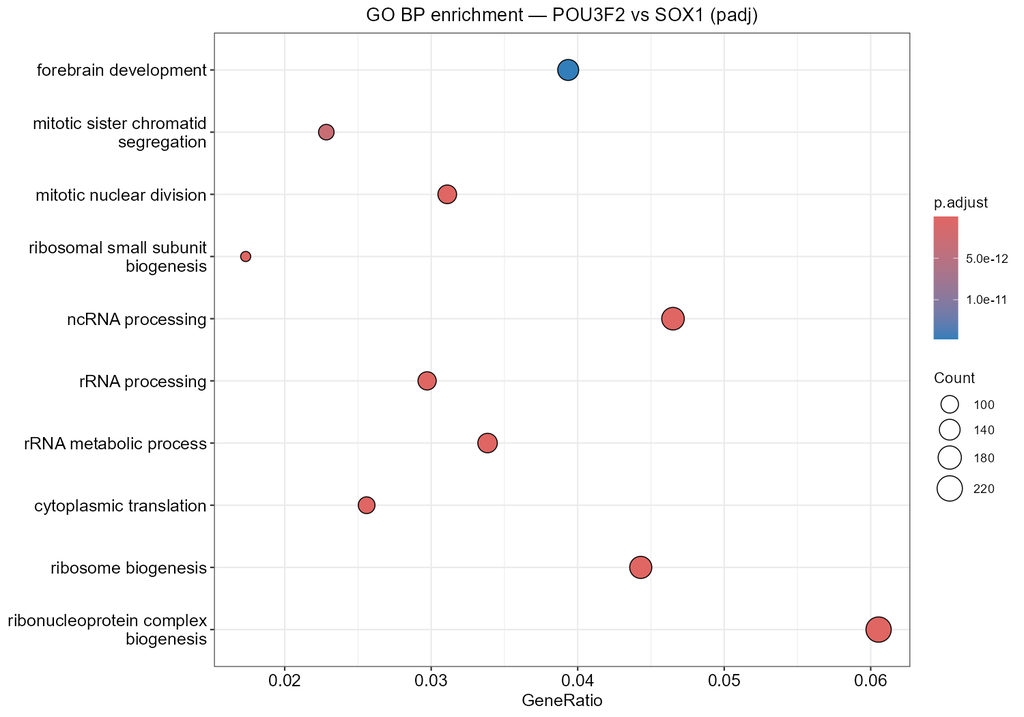

### Findings:

- Ribosome biogenesis
- rRNA processing
- Cell division (chromatid segregation)
- Forebrain development